# chl-indicator-comparison-calculations

Matt Callahan

6/23/2022

The actual calculations of the ESP indicators are performed here. First we will recalculate previously submitted indicators with MODIS data to ensure that we are using the correct processes. Then we will apply the same code to the OC-CCI data. We will compare indicators visually by plotting indicator values over time and against each other, and statistically with simple linear models.

We will also explore ESR chlorophyll indicators, starting with the Southeastern Bering Sea.

## Load data

```r
library(tidyverse)
library(lubridate)
library(sf)
library(httr)
library(flextable)
```

**MODIS** MODIS data were downloaded from a google folder where Jordan stored them from previous efforts https://drive.google.com/drive/u/1/folders/1mhwQ70mjLrkiQYiQ2oNHx08Q7IlL8Q3-

```r
#EBS
mod_ebs<-readRDS("Data/MODIS/merged_8day_2003_2021_EBS.RDS")
#GOA
mod_goa<-readRDS("Data/MODIS/merged_8day_2003_2021_GOA.RDS")
```

**Load oc-cci** This took a couple hundred lines of codes to make, found in chla-indicator-comparison-data.Rmd

```r
occ_esp<-readRDS("Data/OCCCI/occ8_esp_strata.RDS")
```

## ESP indicators

These indicators were requested by stock assessment authors. Each indicator is a single value for each year.

**Previous ESP Indicator descriptions**

```r
#check which indicators were used
ind <- httr::content(httr::GET("https://apex.psmfc.org/akfin/data_marts/akmp/esp_indicators?"),
                      type = "application/json"
) %>%
  dplyr::bind_rows()

ind<-ind%>%filter(grepl('Chlorophylla', INDICATOR_NAME))

#all ours?
unique(ind$CONTACT) #yes
```

```
## [1] "Jordan Watson" "Jens Nielsen"
```

```r
#Descriptions
ind%>%group_by(INDICATOR_NAME)%>%
  summarise(descritption=unique(PRODUCT_DESCRIPTION),
            submission_year=unique(SUBMISSION_YEAR))%>%
   flextable()%>%
  theme_box()
```

| INDICATOR_NAME | descritption | submission_year |
| --- | --- | --- |
| AMJ_Chlorophylla_Biomass_SEBS_Satellite | April-June average chlorophyll-a biomass within the north middle shelf of the EBS; calculated with 8-day composite data from MODIS satellites aggregated by BSIERP region | 2022 |
| Spring_Chlorophylla_Biomass_EGOA_Satellite | Derived chlorophyll a concentration data during spring seasonal peak (May) in the eastern GOA were obtained from the 4km Ocean Colour Climate Change Initiative (OC-CCI) version 4.0 monthly gridded dat… | 2019 |
| Spring_Chlorophylla_Biomass_SEBS_Inner_Shelf_Satellite | Chlorophyll a biomass was calculated as the April-June average chlorophyll-a estimates from MODIS satellites within the Southern Inner Shelf of the Bering Sea. Code available at: https://github.com/jo… | 2020 |
| Spring_Chlorophylla_Biomass_SEBS_Satellite | Derived chlorophyll a concentration during spring seasonal peak (May) in the southeastern Bering Sea were obtained from MODIS satellite sensor at a 4x4 km resolution and aggregated 8-day composite. Pe… | 2019 |
| Spring_Chlorophylla_Biomass_SMBKC_Satellite | Chlorophyll a Biomass: April-June average chlorophyll-a biomass within the St. Matthew region of the Bering Sea; calculated with 8-day composite data from MODIS satellites. https://github.com/jordanwa… | 2020 |
| Spring_Chlorophylla_Biomass_WCGOA_Satellite | Derived chlorophyll a concentration data during spring seasonal peak (May) in the western and central GOA were obtained from the 4km Ocean Colour Climate Change Initiative (OC-CCI) version 4.0 monthly… | 2019 |
| Spring_Chlorophylla_Peak_EGOA_Satellite | Derived chlorophyll a concentration during spring seasonal peak (May) in the eastern GOA were obtained from MODIS satellite sensor at a 4x4 km resolution and aggregated 8-day composite. Peak timing of… | 2020 |
| Spring_Chlorophylla_Peak_SEBS_Satellite | Derived chlorophyll a concentration during spring seasonal peak (May) in the southeastern Bering Sea were obtained from MODIS satellite sensor at a 4x4 km resolution and aggregated 8-day composite. Pe… | 2020 |
| Spring_Chlorophylla_Peak_WCGOA_Satellite | Derived chlorophyll a concentration during spring seasonal peak (May) in the western and central (combined) GOA were obtained from MODIS satellite sensor at a 4x4 km resolution and aggregated 8-day co… | 2020 |

**Functions** Create functions for

-comparing MODIS indicators with previous indicators

-joining MODIS and OC indicators

-plotting MODIS and OC indicators over time

-plotting MODIS and OC against each other

```r
#Calculation will differ for each indicator so probably not worth functionalizing that.

#Compare MODIS with previous indicator
#indicator is the INDICATOR_NAME in the ind object
#x is the data frame with the new MODIS indicator
pull_ind<-function(indicator, x) {
  ind%>%filter(INDICATOR_NAME==indicator)%>%
  dplyr::select(YEAR, DATA_VALUE)%>%
  left_join(x, by="YEAR")%>%
  mutate(diff=round(DATA_VALUE-MODIS_VALUE,2))%>%
    print()
}
#sum of differences
sumdiff<-function(x) {
  sum(x$diff)
}

#join
chla_join<-function(occci,mod) {
  occci%>% left_join(mod, by=c("year"="YEAR"))
}

#plot over time
chla_timeplot<-function(x, indicator) {
  x%>%
  ggplot()+
  geom_line(aes(x=year,y=OCCCI_VALUE), color="red")+
  geom_line(aes(x=year,y=MODIS_VALUE), color="blue")+
  ylab("chla")+
  ggtitle(paste(indicator, " OC-CCI=red, MODIS=blue"))
}

#equation functions
lm_eqn <- function(df){
    m <- lm(OCCCI_VALUE ~ MODIS_VALUE, df);
    eq <- substitute(italic(y) == a + b %.% italic(x)*","~~italic(r)^2~"="~r2,
         list(a = format(unname(coef(m)[1]), digits = 2),
              b = format(unname(coef(m)[2]), digits = 2),
             r2 = format(summary(m)$r.squared, digits = 3)))
    as.character(as.expression(eq));
}

chla_reg_plot<-function(df, indicator){
  ggplot(data=df, aes(x=MODIS_VALUE, y=OCCCI_VALUE, label=year))+
    geom_point()+
    geom_text()+
    geom_smooth(method="lm")+
    annotate(geom='text', label = lm_eqn(df), parse = TRUE, x=-Inf, y=Inf, hjust=0, vjust=1)+
    ggtitle(indicator)+
    geom_abline(slope=1, intercept=0, lty=2)

}
```

**AMJ_Chlorophylla_Biomass_SEBS_Satellite**

```r
#define indicator
indicator<-"AMJ_Chlorophylla_Biomass_SEBS_Satellite"
#MODIS
#recalculate indicator
mod_AMJ_SEBS <- mod_ebs %>%
  mutate(month=month(date),
         YEAR=year(date)) %>%
  filter(bsierp_name== "North middle shelf" & month%in%c(4:6)) %>%
  group_by(YEAR) %>%
  summarise(MODIS_VALUE=mean(chlorophyll,na.rm=TRUE))

#join with previous indicator and compare
temp<-pull_ind(indicator, mod_AMJ_SEBS)
```

```
## # A tibble: 19 x 4
##     YEAR DATA_VALUE MODIS_VALUE  diff
##    <dbl>      <dbl>       <dbl> <dbl>
##  1  2021      2.62        2.97  -0.35
##  2  2020      2.88        1.50   1.38
##  3  2019      1.77        2.73  -0.95
##  4  2018      2.42        2.00   0.42
##  5  2017      2.36        7.17  -4.81
##  6  2016      1.76        0.684  1.07
##  7  2015      2.71        3.94  -1.24
##  8  2014      1.78        1.21   0.56
##  9  2013      1.92        1.35   0.57
## 10  2012      1.15        1.19  -0.04
## 11  2011      1.19        2.18  -0.99
## 12  2010      1.97        1.43   0.54
## 13  2009      2.49        1.14   1.35
## 14  2008      1.47        1.19   0.27
## 15  2007      0.992       1.06  -0.07
## 16  2006      1.40        1.86  -0.46
## 17  2005      1.85        2.03  -0.18
## 18  2004      3.19        1.77   1.41
## 19  2003      3.02        0.987  2.03
```

```r
#Values different. Follow up with Jens
```

**Spring_Chlorophylla_Biomass_EGOA_Satellite**

```r
#define indicator
indicator<-"Spring_Chlorophylla_Biomass_EGOA_Satellite"
#MODIS
#recalculate indicator
mod_SPR_EGOA_B <- mod_goa %>%
  mutate(month=month(date),
         YEAR=year(date)) %>%
  filter(nmfsarea %in% c(640,650) & month==5 & depth<(-10) & depth>(-200)) %>%
  group_by(YEAR) %>%
  summarise(MODIS_VALUE=mean(chlorophyll,na.rm=TRUE))

#join with previous indicator and compare
temp<-pull_ind(indicator, mod_SPR_EGOA_B)
```

```
## # A tibble: 19 x 4
##     YEAR DATA_VALUE MODIS_VALUE  diff
##    <dbl>      <dbl>       <dbl> <dbl>
##  1  2021       3.23        3.23     0
##  2  2020       1.95        1.95     0
##  3  2019       4.29        4.29     0
##  4  2018       2.75        2.75     0
##  5  2017       2.38        2.38     0
##  6  2016       3.38        3.38     0
##  7  2015       4.7         4.70     0
##  8  2014       7.27        7.27     0
##  9  2013       4.41        4.41     0
## 10  2012       1.44        1.44     0
## 11  2011       2.65        2.65     0
## 12  2010       5.52        5.52     0
## 13  2009       4.73        4.73     0
## 14  2008       4.43        4.43     0
## 15  2007       2.34        2.34     0
## 16  2006       2.58        2.58     0
## 17  2005       4.37        4.37     0
## 18  2004       5.37        5.37     0
## 19  2003       4.55        4.55     0
```

```r
sumdiff(temp)
```

```
## [1] 0
```

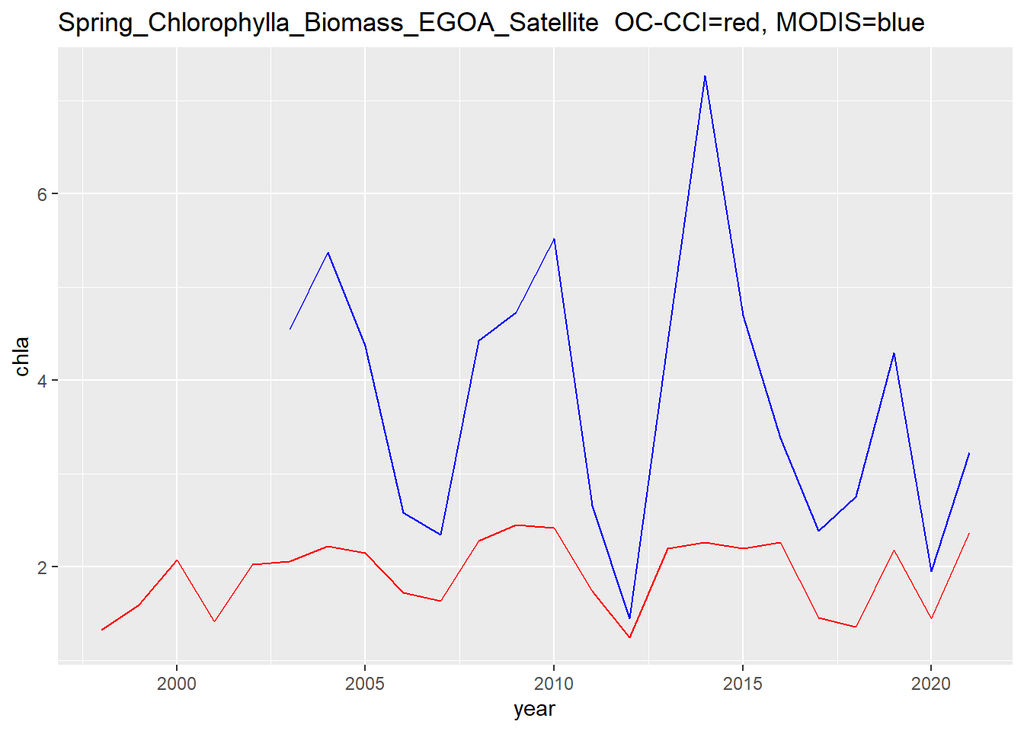

```r
#Curious that this matches exactly when the indicator description says it uses oc-cci

#OCC
occci_SPR_EGOA_B<-occ_esp%>%
  filter(NMFS_REP_AREA%in% c(640, 650) & month==5 & depth<(-10) & depth>(-200))%>%
   group_by(year) %>%
  summarise(OCCCI_VALUE=mean(chlorophyll,na.rm=TRUE))

#join
SPR_EGOA_B_chla<-chla_join(occci_SPR_EGOA_B, mod_SPR_EGOA_B)

#plot
#timeseries
chla_timeplot(SPR_EGOA_B_chla, indicator)
```

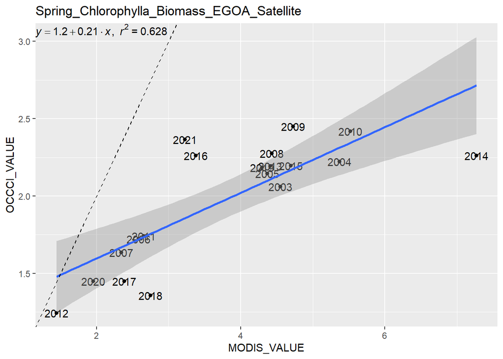

```r
#regression
fit<-lm_eqn(SPR_EGOA_B_chla)
chla_reg_plot(SPR_EGOA_B_chla, indicator)
```

**Spring_Chlorophylla_Biomass_SEBS_Inner_Shelf_Satellite**

```r
#define indicator
indicator<-"Spring_Chlorophylla_Biomass_SEBS_Inner_Shelf_Satellite"
#MODIS
#recalculate indicator
mod_BB <- mod_ebs %>%
  mutate(month=month(date),
         YEAR=year(date)) %>%
  filter(crab=="BristolBay" & month%in%c(4:6)) %>%
  group_by(YEAR) %>%
  summarise(MODIS_VALUE=mean(chlorophyll,na.rm=TRUE))

#join with previous indicator and compare
temp<-pull_ind(indicator, mod_BB)
```

```
## # A tibble: 19 x 4
##     YEAR DATA_VALUE MODIS_VALUE  diff
##    <dbl>      <dbl>       <dbl> <dbl>
##  1  2021       2.49        2.49     0
##  2  2020       2.53        2.53     0
##  3  2019       2.24        2.24     0
##  4  2018       2.10        2.10     0
##  5  2017       1.95        1.95     0
##  6  2016       2.37        2.37     0
##  7  2015       3.95        3.95     0
##  8  2014       4.28        4.28     0
##  9  2013       2.97        2.97     0
## 10  2012       2.86        2.86     0
## 11  2011       2.90        2.90     0
## 12  2010       4.16        4.16     0
## 13  2009       3.16        3.16     0
## 14  2008       2.20        2.20     0
## 15  2007       2.11        2.11     0
## 16  2006       2.00        2.00     0
## 17  2005       2.87        2.87     0
## 18  2004       3.79        3.79     0
## 19  2003       3.13        3.13     0
```

```r
sumdiff(temp)
```

```
## [1] 0
```

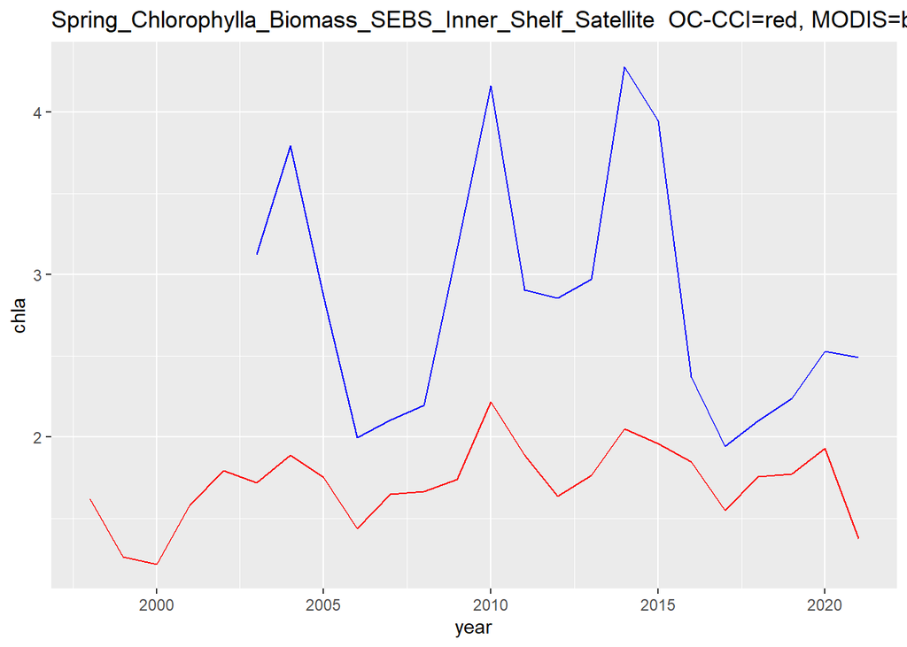

```r
#OCcci
occci_BB<-occ_esp%>%
  filter(BS_KING=="BBRKC" & month%in%c(4:6))%>%
   group_by(year) %>%
  summarise(OCCCI_VALUE=mean(chlorophyll,na.rm=TRUE))

#join
BB_chla<-chla_join(occci_BB, mod_BB)

#plot
#timeseries
chla_timeplot(BB_chla, indicator)
```

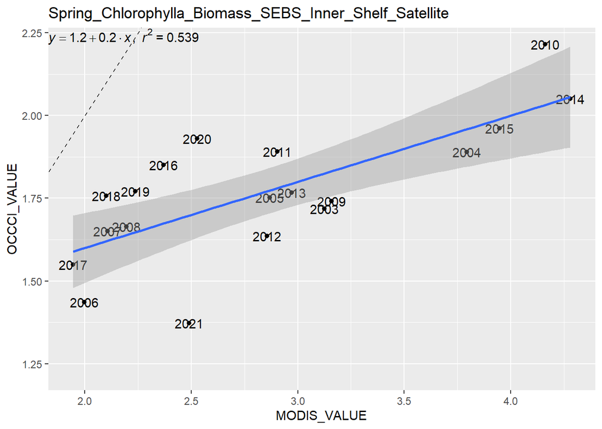

```r
#regression
fit<-lm_eqn(BB_chla)
chla_reg_plot(BB_chla, indicator)
```

**Spring_Chlorophylla_Biomass_SEBS_Satellite**

```r
#define indicator
indicator<-"Spring_Chlorophylla_Biomass_SEBS_Satellite"
#MODIS
#recalculate indicator
mod_SEBS5 <- mod_ebs %>%
  mutate(month=month(date),
         YEAR=year(date)) %>%
  filter(Ecosystem_sub=="Southeastern Bering Sea" & month==5) %>%
  #filter(bsierp_name== "North middle shelf" & month%in%c(4:6)) %>%
  group_by(YEAR, stat_area) %>%
  summarise(MODIS_INTERMEDIATE=mean(chlorophyll,na.rm=TRUE))%>%
  group_by(YEAR)%>%
  summarise(MODIS_VALUE=mean(MODIS_INTERMEDIATE,na.rm=TRUE))

#join with previous indicator and compare
temp<-pull_ind(indicator, mod_SEBS5)
```

```
## # A tibble: 19 x 4
##     YEAR DATA_VALUE MODIS_VALUE  diff
##    <dbl>      <dbl>       <dbl> <dbl>
##  1  2021       3.03        3.12 -0.09
##  2  2020       3.26        3.07  0.19
##  3  2019       2.26        2.59 -0.33
##  4  2018       2.56        2.33  0.22
##  5  2017       2.06        2.74 -0.67
##  6  2016       2.86        2.66  0.2
##  7  2015       4.49        3.77  0.71
##  8  2014       4.44        3.89  0.56
##  9  2013       2.68        3.00 -0.33
## 10  2012       2.68        2.85 -0.17
## 11  2011       3.36        3.57 -0.21
## 12  2010       3.27        3.60 -0.33
## 13  2009       4.21        4.73 -0.52
## 14  2008       3.00        3.07 -0.07
## 15  2007       1.86        2.79 -0.93
## 16  2006       2.50        3.12 -0.62
## 17  2005       3.23        3.16  0.08
## 18  2004       4.99        4.45  0.54
## 19  2003       3.56        4.08 -0.53
```

```r
#Values different. Follow up with Jens
```

**Spring_Chlorophylla_Biomass_SMBKC_Satellite** Calculations from https://github.com/jordanwatson/ESP_Indicators/blob/main/ESP_Chlorophyll_Crab.R

```r
#define indicator
indicator<-"Spring_Chlorophylla_Biomass_SMBKC_Satellite"
#MODIS
#recalculate indicator
mod_smbkc <- mod_ebs %>%
  mutate(month=month(date),
         YEAR=year(date)) %>%
  filter(crab=="StMatts" & month%in%c(4:6)) %>%
  group_by(YEAR) %>%
  summarise(MODIS_VALUE=mean(chlorophyll,na.rm=TRUE))

#join with previous indicator and compare
temp<-pull_ind(indicator, mod_smbkc)
```

```
## # A tibble: 19 x 4
##     YEAR DATA_VALUE MODIS_VALUE  diff
##    <dbl>      <dbl>       <dbl> <dbl>
##  1  2021      3.20        3.20      0
##  2  2020      3.01        3.01      0
##  3  2019      2.07        2.07      0
##  4  2018      2.78        2.78      0
##  5  2017      3.46        3.46      0
##  6  2016      1.56        1.56      0
##  7  2015      2.76        2.76      0
##  8  2014      2.99        2.99      0
##  9  2013      1.20        1.20      0
## 10  2012      0.506       0.506     0
## 11  2011      1.17        1.17      0
## 12  2010      1.54        1.54      0
## 13  2009      2.57        2.57      0
## 14  2008      1.33        1.33      0
## 15  2007      0.803       0.803     0
## 16  2006      1.90        1.90      0
## 17  2005      2.09        2.09      0
## 18  2004      3.86        3.86      0
## 19  2003      3.94        3.94      0
```

```r
sumdiff(temp)
```

```
## [1] 0
```

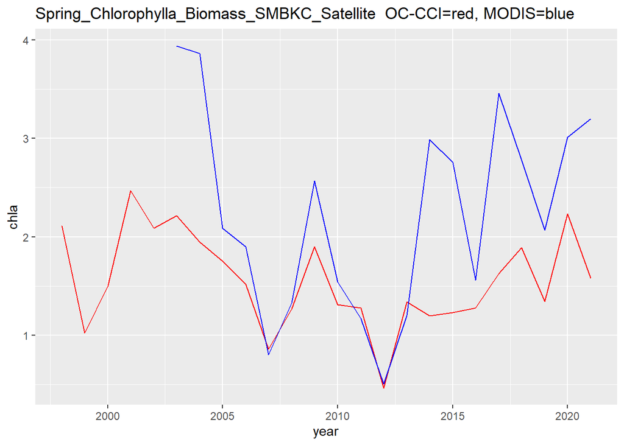

```r
#OCcci
occci_smbkc<-occ_esp%>%
  filter(BS_KING=="StMattBKC" & month%in%c(4:6))%>%
   group_by(year) %>%
  summarise(OCCCI_VALUE=mean(chlorophyll,na.rm=TRUE))

#join
smbkc_chla<-chla_join(occci_smbkc, mod_smbkc)

#plot
#timeseries
chla_timeplot(smbkc_chla, indicator)
```

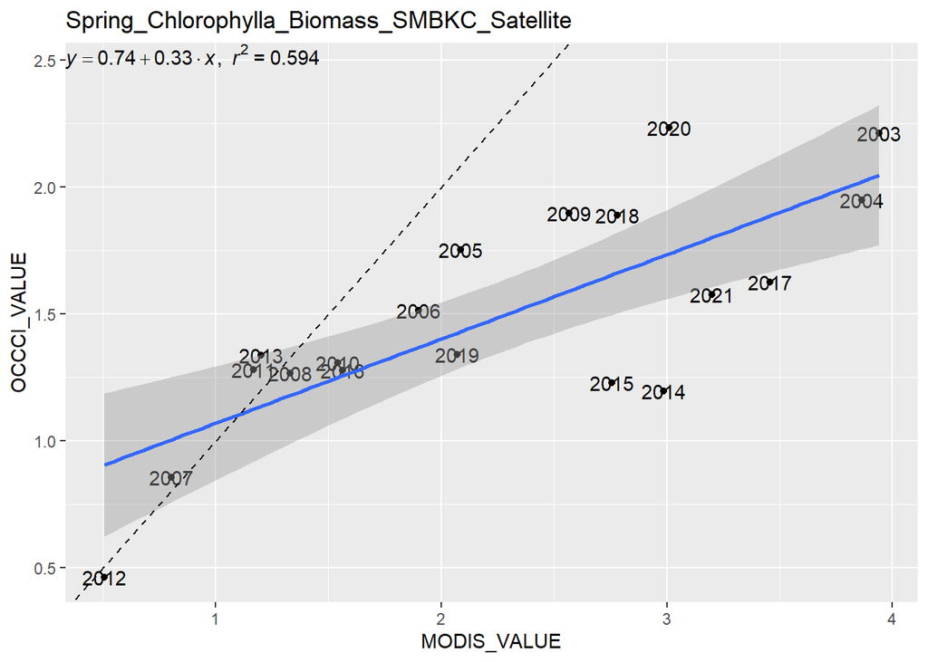

```r
#regression
fit<-lm_eqn(smbkc_chla)
chla_reg_plot(smbkc_chla, indicator)
```

**Spring_Chlorophylla_Biomass_WCGOA_Satellite**

```r
#define indicator
indicator<-"Spring_Chlorophylla_Biomass_WCGOA_Satellite"
#MODIS
#recalculate indicator
mod_SPR_WCGOA_B <- mod_goa %>%
  mutate(month=month(date),
         YEAR=year(date)) %>%
  filter(nmfsarea %in% c(610, 620, 630) & month==5 & depth<(-10) & depth>(-200)) %>%
  group_by(YEAR) %>%
  summarise(MODIS_VALUE=mean(chlorophyll,na.rm=TRUE))

#join with previous indicator and compare
temp<-pull_ind(indicator, mod_SPR_WCGOA_B)
```

```
## # A tibble: 19 x 4
##     YEAR DATA_VALUE MODIS_VALUE  diff
##    <dbl>      <dbl>       <dbl> <dbl>
##  1  2021       2.6         2.68 -0.08
##  2  2020       3.62        3.61  0.01
##  3  2019       2.16        2.17 -0.01
##  4  2018       2.2         2.24 -0.04
##  5  2017       2.19        2.21 -0.02
##  6  2016       2.09        2.12 -0.03
##  7  2015       4.03        4.03  0
##  8  2014       4.23        4.35 -0.12
##  9  2013       3.63        3.70 -0.07
## 10  2012       3.34        3.43 -0.09
## 11  2011       4.88        4.94 -0.06
## 12  2010       2.7         2.77 -0.07
## 13  2009       4.71        4.78 -0.07
## 14  2008       2.67        2.72 -0.05
## 15  2007       3.52        3.58 -0.06
## 16  2006       4.96        5.11 -0.15
## 17  2005       3.64        3.61  0.03
## 18  2004       3.76        3.65  0.11
## 19  2003       3.42        3.31  0.11
```

```r
sumdiff(temp)
```

```
## [1] -0.66
```

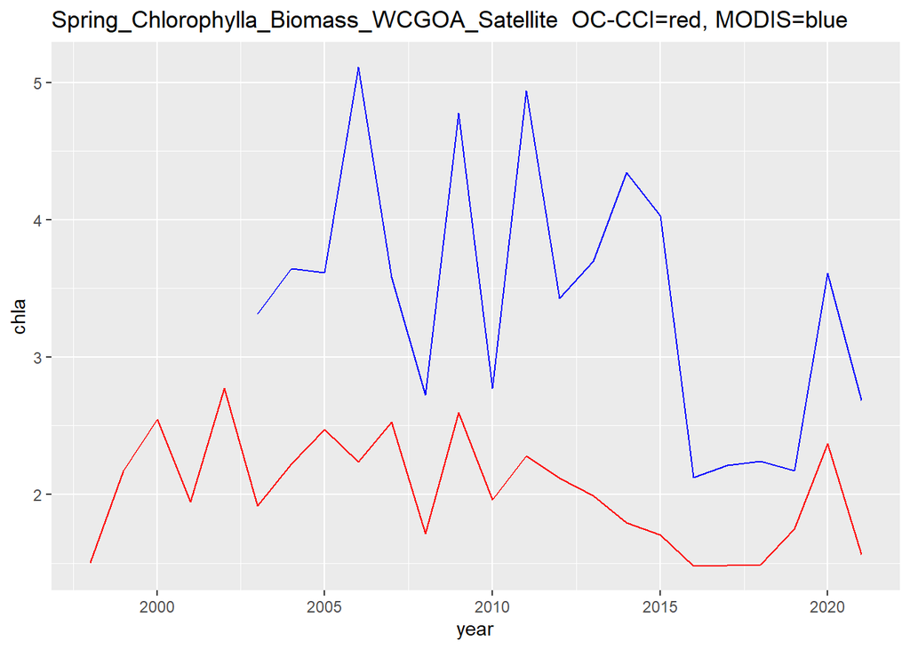

```r
#Close but not quite... Won't be a big deal if we switch out products, if we stick with MODIS it will probably be worth tracking down that difference.

#OCC
occci_SPR_WCGOA_B<-occ_esp%>%
  filter(NMFS_REP_AREA%in% c(610, 620, 630) & month==5 & depth<(-10) & depth>(-200))%>%
   group_by(year) %>%
  summarise(OCCCI_VALUE=mean(chlorophyll,na.rm=TRUE))


#join
SPR_WCGOA_B_chla<-chla_join(occci_SPR_WCGOA_B, mod_SPR_WCGOA_B)

#plot
#timeseries
chla_timeplot(SPR_WCGOA_B_chla, indicator)
```

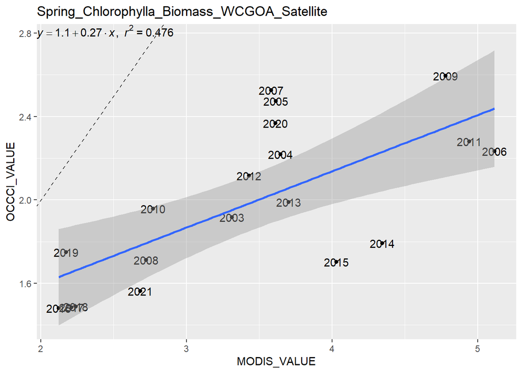

```r
#regression
fit<-lm_eqn(SPR_WCGOA_B_chla)
chla_reg_plot(SPR_WCGOA_B_chla, indicator)
```

## Recalculate ESR indices

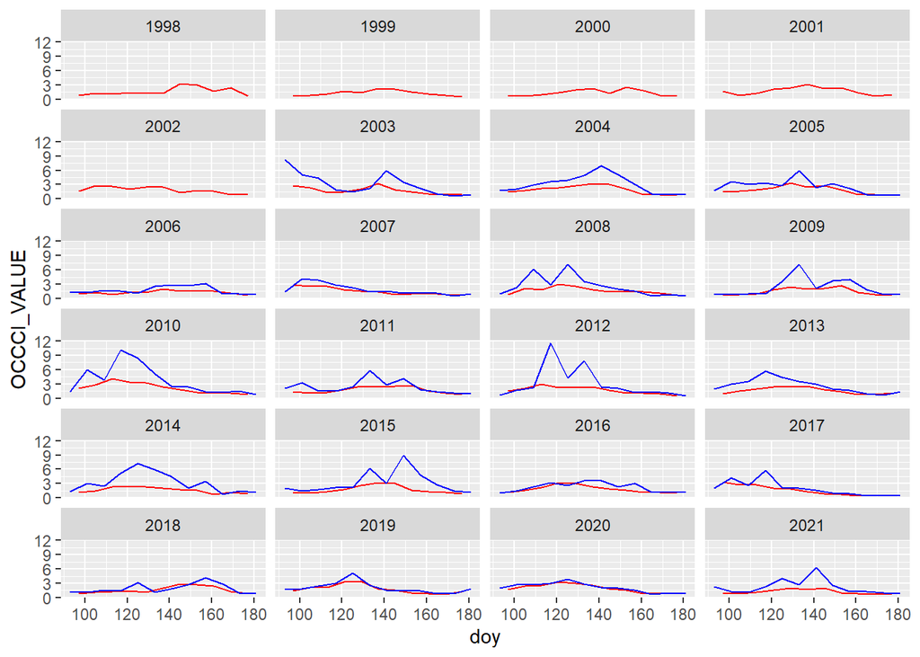

```r
#Select SEBS shelf BS regions
#MODIS
mod_esr<-mod_ebs%>%
  mutate(month=month(date),
         YEAR=year(date),
         doy=yday(date)) %>%
  filter(bsierp_id %in% c(1,3,5,6) & month %in% c(4,5,6))%>%
  group_by(YEAR, doy)%>%
  summarise(MODIS_VALUE=round(mean(chlorophyll, na.rm=T),2))

#oc-cci
#MODIS
occci_esr<-occ_esp%>%
  filter(BSIERP_ID %in% c(1,3,5,6) & month %in% c(4,5,6))%>%
  mutate(doy=yday(date),
         YEAR=year) %>%
  group_by(YEAR, doy)%>%
  summarise(OCCCI_VALUE=round(mean(chlorophyll, na.rm=T),2))

#plot
ggplot()+
  geom_line(data=occci_esr, aes(x=doy, y=OCCCI_VALUE), color="red")+
  geom_line(data=mod_esr, aes(x=doy, y=MODIS_VALUE), color="blue")+
  facet_wrap(~YEAR, ncol=4)
```

```r
#save files for Jens
#saveRDS(mod_esr, "Data/MODIS/modis_south_middle_shelf.RDS")
#saveRDS(mod_esr, "Data/OCCCI/occci_south_middle_shelf.RDS")
#and grouped by stat areas

#MODIS
#mod_ebs%>%
#  mutate(month=month(date),
#         YEAR=year(date)) %>%
#  filter(bsierp_id %in% c(1,3,5,6) & month %in% c(4,5,6))%>%
#  group_by(YEAR, date, stat_area)%>%
#  summarise(MODIS_VALUE=round(mean(chlorophyll, na.rm=T),2))%>%
#  saveRDS("Data/MODIS/MODIS_SEBS_shelf_stat_esr.RDS")
#OC-CCI

#occ_esp%>%
#  filter(BSIERP_ID %in% c(1,3,5,6) & month %in% c(4,5,6))%>%
#  group_by(year, date, STAT_AREA)%>%
#  summarise(OCCCI_VALUE=round(mean(chlorophyll, na.rm=T),2))%>%
#  saveRDS("Data/OCCCI/OCCI_SEBS_shelf_stat_esr.RDS")
```